# Projet Fouille du web

Trésor Djonga

## Étude exploratoire des données

Les données **polbooks.gml** viennent du site de [Mark Newman](http://www-personal.umich.edu/~mejn/netdata/) et concernent les livres publiés sur les politiciens americains lors de l’éléction présidentielle de 2004. Les noeuds sont des livres et sont connectés s’ils ont été achetés par la même personne sur le site d’Amazon.

```r
#Chargement des librairies nécessaires
library(igraph)
library(sna)
library(blockmodels)

#Chargement du dataset
g = read.graph(file="polbooks.gml", format = "gml")

#analyse descriptive du graphe
summary(g)
```

```
## IGRAPH 19145f2 U--- 105 441 --
## + attr: id (v/n), label (v/c), value (v/c)
```

```r
# degré de chaque noeud et moyen
d = igraph::degree(g)
print(d)
```

```
##   [1]  6  4  4 23  8  7 11  8 25 16 15 18 25 13  9  5  3  5  3  5 10  5  7
##  [24]  9  9  5  9  9  3  4 20 11  5  9  5 10  5  7  7  8 18  8  6  5  5  6
##  [47]  4 18  4  8  3  6  5  5  6  4  4  5 13  5  6  4  6  4  9  7 21  6  4
##  [70]  5  7 15 22 21 16 16 13  7  5  8  4  4  9  8 23  5 14  5  5  6  5  8
##  [93]  3  7  7  4  6  6  5 12 12  5  4  2  3
```

```r
#degré moyen
print(mean(d))
```

```
## [1] 8.4
```

```r
# densité du graphe
print(edge_density(g))
```

```
## [1] 0.08076923
```

```r
#nombre possible d'arêtes
print(vcount(g)*(vcount(g)-1)/2)
```

```
## [1] 5460
```

**COMMENTAIRE:** Le graphe contient 105 noeuds ou livres, 441 connexions entre les livres avec une probabilité (densité) de 0.08076923 de connexion entre deux noeuds ou pour qu’une personne achete deux livres. Le nombre de connexions possibles est de 5460 pour un degré moyen de 8.4 par noeud, donc une personne achete en moyenne 8 livres.

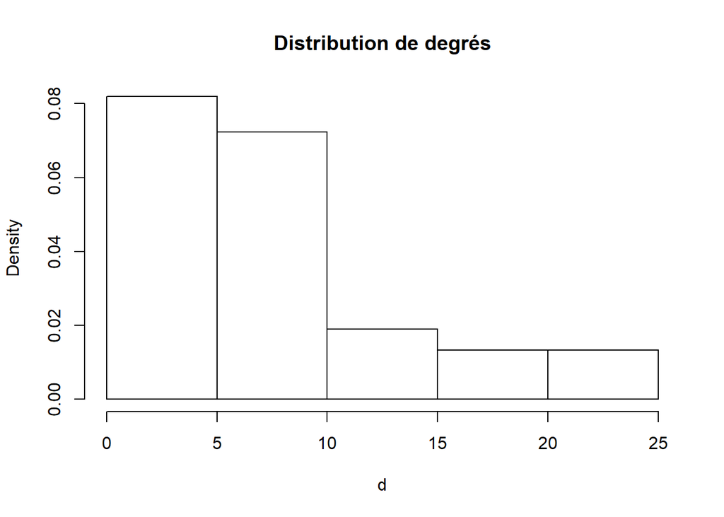

```r
#Histogramme de la distribution des degrés pour noueds du graphe.
hist(d, main = "Distribution de degrés", probability = TRUE)
```

```r
#Visualisation du graphe par l'algorithme de Kamada et Kawai

# matrice d'adjacence
A = get.adjacency(g)

# proprietés de la ma trice adjacente
str(A)
```

```
## Formal class 'dgCMatrix' [package "Matrix"] with 6 slots
##   ..@ i       : int [1:882] 1 2 3 4 5 6 0 3 5 6 ...
##   ..@ p       : int [1:106] 0 6 10 14 37 45 52 63 71 96 ...
##   ..@ Dim     : int [1:2] 105 105
##   ..@ Dimnames:List of 2
##   .. ..$ : NULL
##   .. ..$ : NULL
##   ..@ x       : num [1:882] 1 1 1 1 1 1 1 1 1 1 ...
##   ..@ factors : list()
```

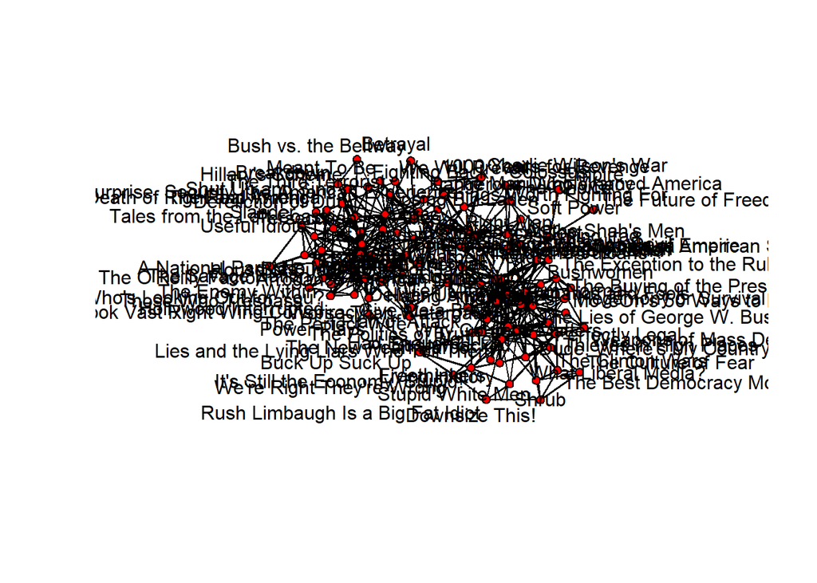

```r
gplot(as.matrix(A), gmode="graph", mode="kamadakawai", label = vertex_attr(g)$label)
```

## Clustering avec SBM

```r
X = as.matrix(A)

res <- BM_bernoulli("SBM", X, plotting="", verbosity=0, ncores=2)

res$estimate() # exécution de la procédure à ce moment là
```

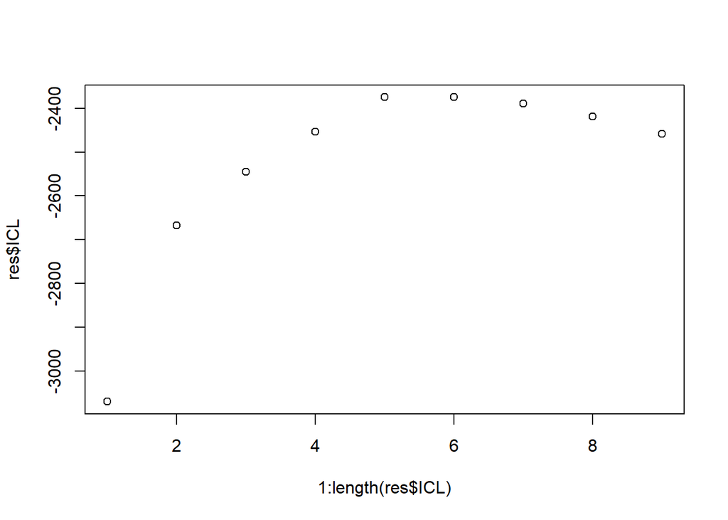

```r
plot(1:length(res$ICL), res$ICL) # critère ICL
```

```r
print(which.max(res$ICL))
```

```
## [1] 6
```

```r
PI = res$model_parameters[[which.max(res$ICL)]] # probabilités de connexion
print(PI)
```

```
## $pi
##              [,1]        [,2]        [,3]         [,4]        [,5]
## [1,] 0.1297899738 0.334495705 0.002618903 0.0007762447 0.001122916
## [2,] 0.3344957046 0.709076045 0.246594682 0.0219351503 0.003106871
## [3,] 0.0026189027 0.246594682 0.169609751 0.0268596973 0.030021670
## [4,] 0.0007762447 0.021935150 0.026859697 0.4256508663 0.050656380
## [5,] 0.0011229157 0.003106871 0.030021670 0.0506563804 0.633538205
## [6,] 0.0035007246 0.001224808 0.002121049 0.0070569165 0.275685165
##             [,6]
## [1,] 0.003500725
## [2,] 0.001224808
## [3,] 0.002121049
## [4,] 0.007056916
## [5,] 0.275685165
## [6,] 0.066387997
##
## $n_parameters
## [1] 36
```

```r
cl = apply(res$memberships[[which.max(res$ICL)]]$Z, 1, which.max)
print(cl)
```

```
##   [1] 3 3 3 2 3 3 3 3 2 2 2 2 2 2 3 1 1 1 3 1 3 1 3 1 3 3 3 1 6 3 5 5 1 1 1
##  [36] 1 1 1 1 1 2 1 1 1 1 3 1 2 3 3 3 4 4 3 1 1 1 3 4 6 6 6 6 6 4 4 5 4 4 4
##  [71] 6 5 5 5 5 5 5 6 6 6 6 6 6 6 5 4 5 6 6 6 6 6 6 6 6 6 6 6 6 5 5 6 6 4 4
```

```r
alpha = table(cl) / vcount(g) # proportions des clusters
print(alpha)
```

```
## cl
##          1          2          3          4          5          6
## 0.21904762 0.08571429 0.20000000 0.10476190 0.12380952 0.26666667
```

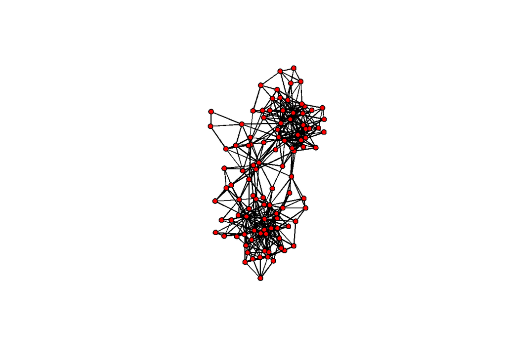

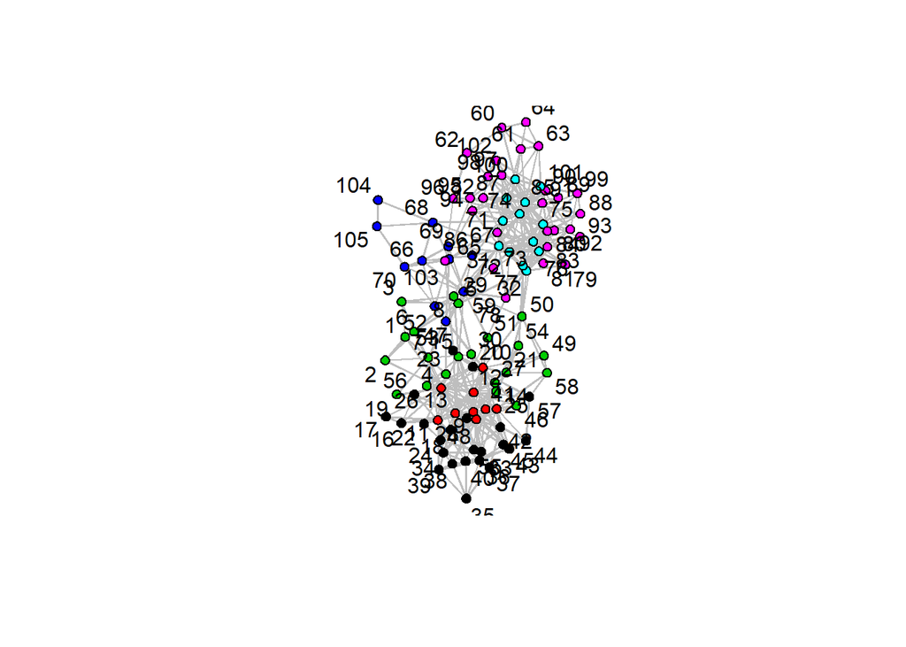

```r
col = cl

sna::gplot(X, gmode="graph", edge.col="gray", vertex.col=col, label=1:vcount(g), coord=gplot(X, gmode="graph"))
```

**COMMENTAIRE::** Le cluster 6 est le plus grand et on a en terme d’effectif: cl6>cl1>cl3>cl5>cl4>cl2. Le nombre de classe optimale est 6. Les classe 1 et 3 se connectent plus à la classe 2, elles sont des communautés, presence forte des probabilités de connexion intraclasse. Les livres de la classe 2 sont plus souvent achètés avec ceux des classes 1 et 3. La classe 4 est une communauté, forte probabilité de connexion interne et très peu connectée aux autres classes. La classe 6 se connecte à la classe 5.

## Détection des communautés: méthode de maximisation de la modularité

```r
# approche de Louvain
g1 = graph.adjacency(X, mode="undirected")

res = cluster_louvain(g1)

cl = membership(res)

# proportions des communautés
alpha = table(cl) / vcount(g)
print(alpha)
```

```
## cl
##         1         2         3         4
## 0.1714286 0.3333333 0.1047619 0.3904762
```

```r
num_com = c(cl)
num_value = c(igraph::vertex_attr(g, "value"))

books = data.frame(classe = num_com, politics_views = num_value)

#croisement opinion par communauté
op = prop.table(table(books$classe, books$politics_views), margin=1)

print(op)
```

```
##
##              c          l          n
##   1 0.72222222 0.00000000 0.27777778
##   2 0.94285714 0.00000000 0.05714286
##   3 0.18181818 0.45454545 0.36363636
##   4 0.02439024 0.92682927 0.04878049
```

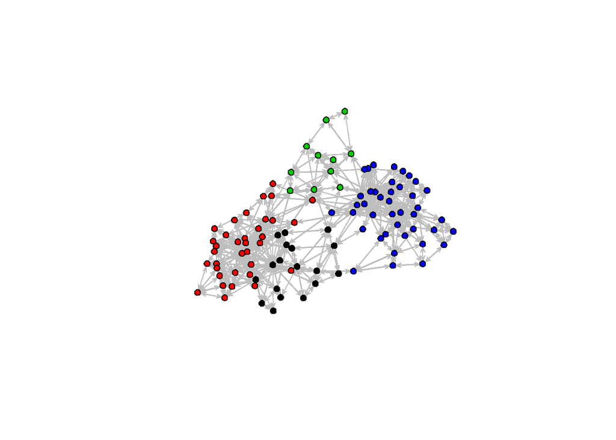

```r
sna::gplot(X, edge.col="gray", vertex.col=cl)
```

**COMMENTAIRE::** Quatre communautés son trouvées. La quatrième est la plus grande en terme d’effectif. Les communautés 1 et 2 sont constituées des conservateurs (c). La comunauté 4 est composée des libéreaux et la communauté est une poubelle